## Younes Essafouri, Aymane Haoulani, Aymane El-Achab

## 1. Import the data

Let’s import the training and testing data sets first.

```r
  # Import the data sets
training_data <- read.csv("train.csv")
testing_data <- read.csv("test.csv")
testing_data$Survived <- rep(NA,nrow(testing_data))
whole_dataset <- rbind(training_data,testing_data)

  # Drop ColumnId
columns_to_drop <- c("PassengerId")
predictors <- whole_dataset[,-which(names(training_data) %in% columns_to_drop)]
#predictors
```

## 2. Managing categorical variables

$\textbf{Name}$

There’s clearly little to no information that we can draw from someone’s complete name. Nevertheless, it’s worth considering his title since it may be correlated to his social/marital status and/or age. And in order to do so, it is necessary to work with regular expressions:

```r
# Method that extracts the title
extract_title <- function(name) {
  title <- gsub("^.*?, (\\w+)\\..*$", "\\1", name)
  return(title)
}

# Apply the function to each name in the 'Name' column
titles <- sapply(predictors$Name, extract_title)

# Add a new column 'Title' to the data frame
predictors$Title <- titles
# Removal of the 'Name' column
predictors <- predictors[,-which(names(predictors) == "Name")]
```

Let’s see the titles of our data set using the table method

```r
# Uncomment to display the result
#sort(table(predictors$Title))
```

It’s clear that ‘Mr’, ‘Miss’, ‘Mrs’ and ‘Master’ are the most common titles. Therefore, these are the ones that will be interesting to us (remaining titles will be associated to an ‘Other’ state)

```r
mr_synonyms <- which(predictors$Title %in% c("Capt", "Col", "Major", "Sir","Don","Dr"))
predictors$Title[mr_synonyms]<- rep("Mr",length(mr_synonyms))
# Find rows where Title is not among specified titles
rows_with_uncommon_titles <- which(!(predictors$Title %in% c("Mr", "Miss", "Mrs", "Master")))
predictors[rows_with_uncommon_titles,c("Title")] <- "Other"
predictors
```

| Survived | Pclass | Sex | Age | SibSp | Parch | Ticket | Fare | Cabin | Embarked | Title |
| --- | --- | --- | --- | --- | --- | --- | --- | --- | --- | --- |
| 0 | 3 | male | 22.00 | 1 | 0 | A/5 21171 | 7.2500 |  | S | Mr |
| 1 | 1 | female | 38.00 | 1 | 0 | PC 17599 | 71.2833 | C85 | C | Mrs |
| 1 | 3 | female | 26.00 | 0 | 0 | STON/O2. 3101282 | 7.9250 |  | S | Miss |
| 1 | 1 | female | 35.00 | 1 | 0 | 113803 | 53.1000 | C123 | S | Mrs |
| 0 | 3 | male | 35.00 | 0 | 0 | 373450 | 8.0500 |  | S | Mr |
| 0 | 3 | male | NA | 0 | 0 | 330877 | 8.4583 |  | Q | Mr |
| 0 | 1 | male | 54.00 | 0 | 0 | 17463 | 51.8625 | E46 | S | Mr |
| 0 | 3 | male | 2.00 | 3 | 1 | 349909 | 21.0750 |  | S | Master |
| 1 | 3 | female | 27.00 | 0 | 2 | 347742 | 11.1333 |  | S | Mrs |
| 1 | 2 | female | 14.00 | 1 | 0 | 237736 | 30.0708 |  | C | Mrs |

[output cut: 1299 more lines]

Final tweak:

```r
# Categorical data ritual
predictors$Title <- factor(predictors$Title)
```

$\textbf{Ticket}$

Now,we need to check whether there is important information that we can draw from the ticket. Otherwise, this column needs to be dropped.

Let’s explore first the potential patterns that we can draw from our Ticket column using the table method:

```r
# This line was commented since the result was too long
#sort(table(predictors$Ticket))
```

Let’s dive into the information of a certain group that shares the same ticket :

```r
predictors[which(predictors$Ticket=="CA. 2343"),]
```

|  | Survived | Pclass | Sex | Age | SibSp | Parch | Ticket | Fare | Cabin | Embarked | Title |
| --- | --- | --- | --- | --- | --- | --- | --- | --- | --- | --- | --- |
| 160 | 0 | 3 | male | NA | 8 | 2 | CA. 2343 | 69.55 |  | S | Master |
| 181 | 0 | 3 | female | NA | 8 | 2 | CA. 2343 | 69.55 |  | S | Miss |
| 202 | 0 | 3 | male | NA | 8 | 2 | CA. 2343 | 69.55 |  | S | Mr |
| 325 | 0 | 3 | male | NA | 8 | 2 | CA. 2343 | 69.55 |  | S | Mr |
| 793 | 0 | 3 | female | NA | 8 | 2 | CA. 2343 | 69.55 |  | S | Miss |
| 847 | 0 | 3 | male | NA | 8 | 2 | CA. 2343 | 69.55 |  | S | Mr |
| 864 | 0 | 3 | female | NA | 8 | 2 | CA. 2343 | 69.55 |  | S | Miss |
| 1080 | NA | 3 | female | NA | 8 | 2 | CA. 2343 | 69.55 |  | S | Miss |
| 1234 | NA | 3 | male | NA | 1 | 9 | CA. 2343 | 69.55 |  | S | Mr |
| 1252 | NA | 3 | male | 14.5 | 8 | 2 | CA. 2343 | 69.55 |  | S | Master |

[output cut: 1 more lines]

We observe that there isn’t much additional information that we can draw from the Ticket column since people sharing the same ticket share the same Fare as well.

```r
predictors <- predictors[,-which(names(predictors)=="Ticket")]
```

$\textbf{Cabin}$

The available data regarding the Cabin of the different passengers is very sparse. So there may have been a problem while collecting this data. But this lack of information may be an information itself. What if there wasn’t a particular cabin for other passengers? Maybe they were all sharing a wide but dense common area of the ship? Who knows?

As a first step, we need to extract the cabin letter and the seat of each one of the passengers that have their cabin data available.

```r
extract_cabin_info <- function(cabin_data) {
  # Define regular expression pattern to match cabin letter and seat
  pattern <- "([A-Za-z])(\\d+)"

  # Apply regex pattern to cabin data
  matches <- regexec(pattern, cabin_data)

  # Extract cabin letter and seat
  cabin_letter <- regmatches(cabin_data, matches)[[1]][2]
  seat <- regmatches(cabin_data, matches)[[1]][3]

  # Return cabin letter and seat
  return(list(cabin_letter = cabin_letter, seat = seat))
}
```

```r
cabin_letter <- matrix(nrow = nrow(predictors),ncol = 1)
cabin_number <- matrix(nrow = nrow(predictors),ncol = 1)
for (i in 1:nrow(predictors)){
  if(predictors$Cabin[i]!=""){
    cabin_info <- extract_cabin_info(predictors$Cabin[i])
    cabin_letter[i] <- cabin_info$cabin_letter
    cabin_number[i] <- cabin_info$seat
  }
}
predictors$CabinLetter <- cabin_letter
predictors$CabinNumber <- cabin_number
```

Obviously there’s nothing that we can draw from the seats data as it is. Therefore, we propose to divide each cabin into a “front” and a “back” area based on the median value of the seats regarding each cabin.

This seems like a good idea on paper, but due to the lack of data points we decided to preserve the cabin letter column as well for now in order to compare both approaches.

```r
cabin_letters <- unique(predictors$CabinLetter[which(!is.na(predictors$CabinLetter)),])

for (i in 1:length(cabin_letters)){
  current_letter <- cabin_letters[i]
  seats_indices <- which(predictors$CabinLetter==current_letter)
  seats <- as.numeric(cabin_number[seats_indices])
  median_seat <- median(seats)

  # Substitute seat number with "front" or "back" based on median value
  predictors$CabinNumber[seats_indices] <- ifelse(seats <= median_seat, "front", "back")
}

# Re-organize the data set
  # Add the new CabinInfo column to our data set
predictors$CabinInfo <- paste0(predictors$CabinLetter,predictors$CabinNumber)
  # Deal with unavailable data
predictors$CabinInfo[which(predictors$CabinInfo=="NANA")] <- rep("Other",length(which(predictors$CabinInfo=="NANA")))
predictors$CabinLetter[which(is.na(predictors$CabinLetter))] <- rep("Other",length(which(is.na(predictors$CabinLetter))))
  # Eliminate CabinNumber and Cabin columns from the data set
predictors <- predictors[,-which(names(predictors)=="CabinNumber")]
predictors <- predictors[,-which(names(predictors)=="Cabin")]
```

```r
# Change the class so that the columns will be considered as categorical
predictors$CabinInfo <- factor(predictors$CabinInfo)
predictors$CabinLetter <- factor(predictors$CabinLetter)
```

$\textbf{Pclass}$,$\textbf{Sex}$ and $\textbf{Embarked}$

Same procedure:

```r
predictors$Pclass <- factor(predictors$Pclass)
predictors$Sex <- factor(predictors$Sex)
predictors$Embarked <- factor(predictors$Embarked)
```

$\textbf{Parch}$ and $\textbf{SibSp}$

The Parch and SibSp variables as they are seem a little bit ambiguous. Therefore, we decided to agregate them into something that would make more sense. In this logic, we decided to explore how families on board affect the survival of each other. Let’s explore how the number of individuals of a family/group affect the chance of survival:

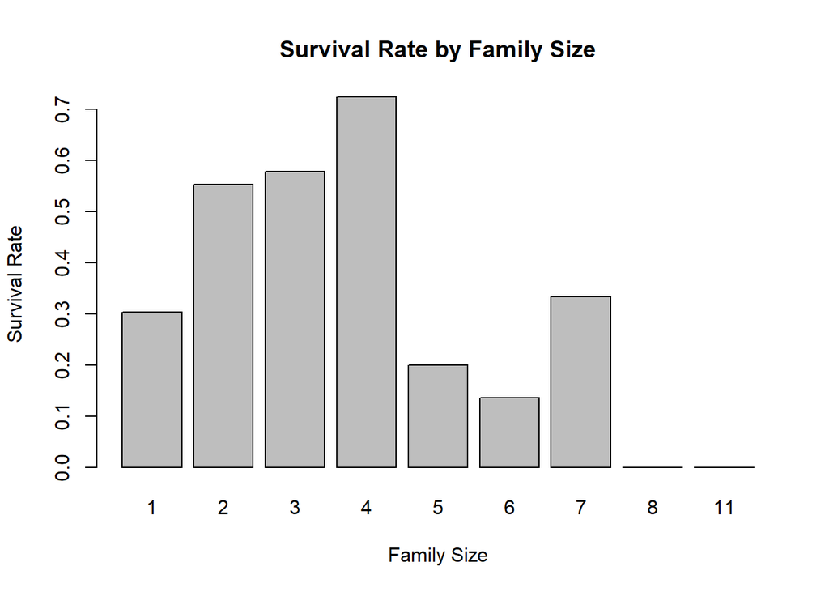

```r
  # Calculate family size
familySize<-training_data$Parch+training_data$SibSp+1
  # Combine family size with survival status
family_survival<-data.frame(familySize,Survived=training_data$Survived)
  # Calculate survival rate for each family size category
survival_rates<-aggregate(Survived~familySize,data=family_survival,FUN=function(x) sum(x)/length(x))
  # Plot survival rate for each family size
barplot(survival_rates$Survived, names.arg=survival_rates$familySize,xlab = "Family Size", ylab = "Survival Rate", main = "Survival Rate by Family Size")
```

We can see that the survival rate increases with the number of individuals of a family/group while this number doesn’t exceed 4. Whereas in the oposite case, it’s the other way around.

This variable will be called ‘GroupType’.

```r
  # Build the desired column
groupSize<-predictors$Parch+predictors$SibSp+1
predictors$GroupType[groupSize==1]<-'Alone'
predictors$GroupType[groupSize<5 & groupSize!=1]<-'Medium'
predictors$GroupType[groupSize>4]<-'Large'
  # Declare it as a categorical variable
predictors$GroupType <- as.numeric(factor(predictors$GroupType))
```

## 3. Dealing with missing values

We observe that our training dataset lacks some values regarding particularly the Age and Cabin columns. And in order to resolve this situation, many strategies remain possible:

- Dropping data points with Missing Values (DMV)

```r
rows_to_drop <- which(is.na(predictors[,c("Age")]))
predictors_DMV <- predictors[-rows_to_drop,]
proportion_of_missing_data <- 1-nrow(predictors_DMV)/nrow(predictors)

cat("The proportion of missing data  is : ",proportion_of_missing_data)
```

```
## The proportion of missing data  is :  0.2009167
```

It is clear that dropping the non-complete data points isn’t the way to go since we will be losing valuable information (~20% of the data). Let’s explore now other approaches:

- Filling the Missing Values with an arbitrary value (Mean/Median):
- Age variable (20% of missing values)

```r
predictors_FMVMean <- predictors
predictors_FMVMedian <- predictors
  # Replace the missing values using the mean value
value_to_replace_with <- mean(predictors_FMVMean[-rows_to_drop,c("Age")])
predictors_FMVMean[rows_to_drop,c("Age")] <- rep(value_to_replace_with,times=length(rows_to_drop))
  # Use the median instead
value_to_replace_with <- median(predictors_FMVMean[-rows_to_drop,c("Age")])
predictors_FMVMedian[rows_to_drop,c("Age")] <- rep(value_to_replace_with,times=length(rows_to_drop))
```

*Fare variable (a single data point)

Since we’re talking about a single missing data point, there’s no need to adopt some fancy approach to complete our data set, it would be simpler to conduct the analysis ourselves. We observe that the concerned individual has a Pclass of 3 and is traveling alone. Therefore, a good estimation of the fare he payed would be nothing but the median value.

```r
# Filter the dataset based on the specified conditions and extract the "Fare" column
a<-which(is.na(predictors$Fare))
fare_subset <- predictors$Fare[which((predictors$Pclass == 3) &
                                       (predictors$SibSp == 0) &
                                       (predictors$Parch == 0))]

# Calculate the median of the extracted "Fare" column
fare_median <- median(fare_subset, na.rm = TRUE)

# Replace missing values in the "Fare" column with the calculated median
predictors[which(is.na(predictors$Fare)), "Fare"] <- fare_median
```

- Trying to predict the age variable following a slightly more sophisticated approach:

In order to choose the best way to predict the missing “Age” values, we need first to investigate the correlation between the Age variable and the other columns.

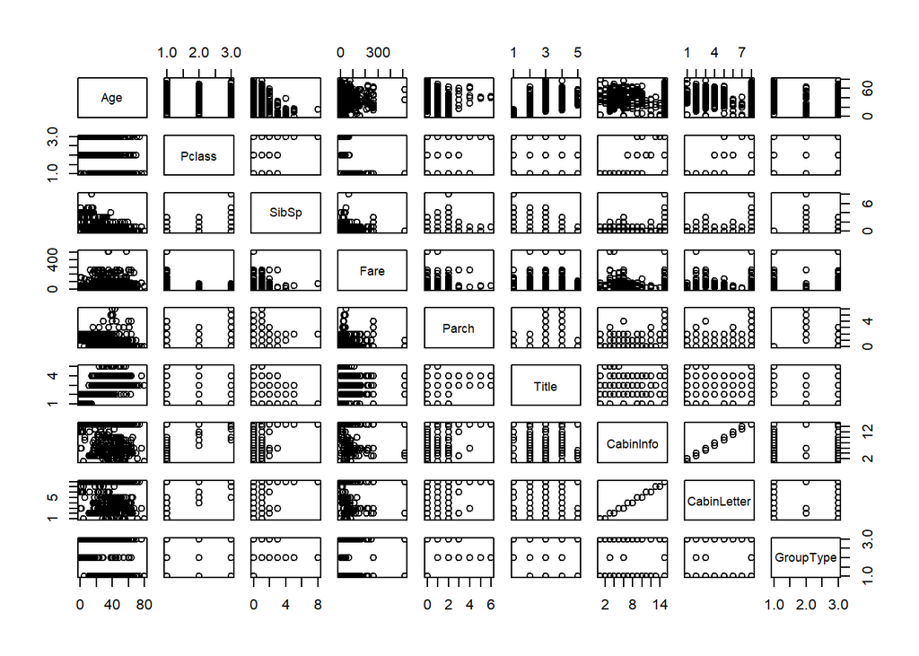

```r
ageCorrelationAnalysis <- pairs(predictors[-rows_to_drop,c("Age","Pclass", "SibSp","Fare","Parch","Title","CabinInfo","CabinLetter","GroupType")])
```

It seems that there is a potential correlation between the Age and some of the other variables, let’s further investigate this observation using a cross-validation based approach:

```r
compute_error_using_CV <- function(training_data,shuffled_indices,useMean,useMedian){

  # We choose the number of folds
  num_folds <- 6
  step <- as.integer(nrow(training_data)/num_folds)

  # Initialization of the vector to store testing errors
testing_errors <- numeric(num_folds)

  # Perform cross-validation
  for (fold in 1:num_folds) {

    # Create indices for training and testing data for this fold
    test_indices <- shuffled_indices[fold:(fold+step)]
    train_indices <- setdiff(1:nrow(training_data), test_indices)

    # Split the data into training and testing sets
    train_data <- training_data[train_indices, ]
    test_data <- training_data[test_indices, ]

  if(useMean){
    predictions <- mean(train_data$Age)

  }
  else if(useMedian){
    predictions <- median(train_data$Age)
  }
  else{
    m <- glm(Age~.,data=train_data)

    # Make predictions on the testing data
    predictions <- predict(m, newdata=test_data,type="response")
  }

  # Compute testing error (MSE)
  testing_errors[fold] <- mean((test_data$Age - predictions)^2)
  }
  return(testing_errors)

}
```

```r
# Definition of different possible combinations
age_training_data1 <- predictors[-rows_to_drop,c("Age","SibSp","Parch")]
age_training_data2 <- predictors[-rows_to_drop,c("Age","SibSp","Parch","Fare")]
age_training_data3 <- predictors[-rows_to_drop,c("Age","SibSp")]
age_training_data4 <- predictors[-rows_to_drop,c("Age","SibSp","Fare")]
age_training_data5 <- predictors[-rows_to_drop,c("Age","Fare")]
age_training_data6 <- predictors[-rows_to_drop,c("Age","Fare","Title")]
age_training_data7 <- predictors[-rows_to_drop,c("Age","Title")]
age_training_data8 <- predictors[-rows_to_drop,c("Age","SibSp","Fare","Title")]
age_training_data9 <- predictors[-rows_to_drop,c("Age","SibSp","Fare","Title","Parch")]
age_training_data10 <- predictors[-rows_to_drop,c("Age","SibSp","Fare","Title","Parch","CabinInfo")]
age_training_data11 <- predictors[-rows_to_drop,c("Age","Fare","Title","CabinInfo")]
age_training_data12 <- predictors[-rows_to_drop,c("Age","Fare","Title","CabinInfo","GroupType","Pclass")]

# Rearrange the data points
shuffled_indices <- sample(1:nrow(training_data), replace = FALSE)

# Results display
cat("The MSE of the different combinations is : \n")
```

```
## The MSE of the different combinations is :
```

```r
cat("Mean value approach : ",mean(compute_error_using_CV(age_training_data3,shuffled_indices,TRUE,FALSE)),"\n")
```

```
## Mean value approach :  188.9322
```

```r
cat("Median value approach : ",mean(compute_error_using_CV(age_training_data3,shuffled_indices,FALSE,TRUE)),"\n")
```

```
## Median value approach :  190.4984
```

```r
cat("Age,SibSp : ",mean(compute_error_using_CV(age_training_data3,shuffled_indices,FALSE,FALSE)),"\n")
```

```
## Age,SibSp :  182.0937
```

```r
cat("Age,Fare : ",mean(compute_error_using_CV(age_training_data5,shuffled_indices,FALSE,FALSE)),"\n")
```

```
## Age,Fare :  189.7722
```

```r
cat("Age,Title : ",mean(compute_error_using_CV(age_training_data7,shuffled_indices,FALSE,FALSE)),"\n")
```

```
## Age,Title :  139.1734
```

```r
cat("Age,Fare,Title : ",mean(compute_error_using_CV(age_training_data6,shuffled_indices,FALSE,FALSE)),"\n")
```

```
## Age,Fare,Title :  134.7876
```

```r
cat("Age,SibSp,Parch : ",mean(compute_error_using_CV(age_training_data1,shuffled_indices,FALSE,FALSE)),"\n")
```

```
## Age,SibSp,Parch :  179.3144
```

```r
cat("Age,SibSp,Fare : ",mean(compute_error_using_CV(age_training_data4,shuffled_indices,FALSE,FALSE)),"\n")
```

```
## Age,SibSp,Fare :  179.8588
```

```r
cat("Age,SibSp,Fare,Title : ",mean(compute_error_using_CV(age_training_data8,shuffled_indices,FALSE,FALSE)),"\n")
```

```
## Age,SibSp,Fare,Title :  132.0718
```

```r
cat("Age,SibSp,Parch,Fare : ",mean(compute_error_using_CV(age_training_data2,shuffled_indices,FALSE,FALSE)),"\n")
```

```
## Age,SibSp,Parch,Fare :  173.4709
```

```r
cat("Age,SibSp,Parch,Fare,Title : ",mean(compute_error_using_CV(age_training_data9,shuffled_indices,FALSE,FALSE)),"\n")
```

```
## Age,SibSp,Parch,Fare,Title :  130.274
```

```r
cat("Age,SibSp,Parch,Fare,Title,CabinInfo : ",mean(compute_error_using_CV(age_training_data10,shuffled_indices,FALSE,FALSE)),"\n")
```

```
## Age,SibSp,Parch,Fare,Title,CabinInfo :  130.9805
```

```r
cat("Age,Fare,Title,CabinInfo : ",mean(compute_error_using_CV(age_training_data11,shuffled_indices,FALSE,FALSE)),"\n")
```

```
## Age,Fare,Title,CabinInfo :  133.2694
```

```r
cat("Age,Fare,Title,CabinInfo,GroupType,Pclass : ",mean(compute_error_using_CV(age_training_data12,shuffled_indices,FALSE,FALSE)),"\n")
```

```
## Age,Fare,Title,CabinInfo,GroupType,Pclass :  123.2999
```

Indeed and as expected, Title is a great proxy to use in order to estimate the age variable. Therefore, extracting this information from the full name of the passengers was certainly the best way to go.

It is also worth mentioning that this method stays well ahead of a simple imputation using mean or median values.

```r
# In this case, the training data will be the rows that have the Age column filled whereas we use those to predict as the testing set (Although we can't quantify the testing error, we tried earlier to estimate it using a cross-validation based approach on the training set)
ageRegressionModel <- glm(Age~.,data=predictors[-rows_to_drop,c("Age","CabinInfo","Fare","Title","GroupType","Pclass")])
agePredictions <- predict(ageRegressionModel,newdata = predictors[rows_to_drop,c("CabinInfo","Fare","Title","GroupType","Pclass")],type='response')
predictors[rows_to_drop,c("Age")] <- agePredictions
```

Since we know that the Master title generally refers to young kids (<13), we fix our estimations if they do not respect this condition

```r
predictors$Age <- ifelse(predictors$Title=='Master' & predictors$Age>13, 13,predictors$Age)
```

## Model selection

Since there isn’t really a mathematical pattern that we can draw from our data, the algorithms that will likely perform better are the ones that make little assumptions about the structure of the data points. For those reasons, we decided to explore Logistic Regression, Random Forest and XGBoost methods.

```r
#install.packages("xgboost")
#install.packages("randomForest")
#install.packages("pROC")

library(xgboost)
library(randomForest)
library(pROC)
```

Let’s first define the helper functions that given a training and a testing set return the prediction error:

- Logistic Regression:

```r
logistic_regression <- function(train,test){
  # Model training
  logregModel <- glm(Survived~.,data=train,family="binomial")
  # Make predictions on the testing data
  logregProb <- predict(logregModel, newdata=test[,-which(names(train)=="Survived")],type="response")
  logregPredictions <- as.integer(logregProb>0.5)
  # Compute the error
  error<- mean((test$Survived != logregPredictions))
  return(list(error=error,predictions=logregPredictions,prob=logregProb))
}
```

- Random Forest:

```r
random_forest <- function(train,test,nb_tree){
  # Model training
  randomForestModel <- randomForest(Survived~.,data=train,ntree=nb_tree)
  # Make predictions on the testing data
  randomForestPredictions<-predict(randomForestModel, newdata=test[,-which(names(train)=="Survived")],type="response")

  randomForestPredictions <- as.integer(randomForestPredictions>0.48)

  # Compute the error
  error<- mean((test$Survived != randomForestPredictions))
  return(list(error=error,predictions=randomForestPredictions))
}
```

- XGBoost:

```r
xg_Boost <- function(train,test){

  xgb_data <- xgb.DMatrix(data = data.matrix(train[,-which(names(train)=="Survived")]),label=train$Survived)
  xgb_model <- xgboost::xgboost(data = xgb_data, nround = 100, objective = "binary:logistic",verbose = FALSE)
  # Model training
  # Make predictions on the testing data
  xgBoostPredictions <- predict(xgb_model, data.matrix(test[,-which(names(test) == "Survived")]))
  xgBoostPredictions <- as.integer(xgBoostPredictions>0.5)
  # Compute the error
  error<- mean((test$Survived != xgBoostPredictions))
  return(error)
}
```

Since we will be performing a benchmark of the selected methods on our data set, it is important to pay attention to the bias and variance behind each one of the results that we will be getting from our experiments. Therefore, and in order to get a fair estimation of the prediction error, we decided to perform cross validation on our data set where each time a fold plays the role of the validation set. Nevertheless, and since the rows of the training & validation sets are randomly selected, we decided to re-run the process a number of times in order to get an idea about the variance produced by each approach and be able finally to fairly compare the different algorithms.

```r
models_comparator <- function(training_data){

  # Setting of the number of times we'll be re-running the benchmark
  nb_iter <- 30

  # Definition of the error matrix that will hold the prediction errors
  errors_matrix <-  matrix(NA, nrow = nb_iter, ncol = 3)
  colnames(errors_matrix) <- c("LogReg", "RandomForest", "XGBoost")

  # We choose the number of folds
  num_folds <- 7
  step <- as.integer(nrow(training_data)/num_folds)

  # Initialization of the temporary vectors in order to store the testing errors after each CV iteration
  logreg_errors <- numeric(num_folds)
  randomForest_errors <- numeric(num_folds)
  xgBoost_errors <- numeric(num_folds)


  for (i in 1:nb_iter){

    shuffled_indices <- sample(1:nrow(training_data), replace = FALSE)

    # Perform cross-validation
    for (fold in 1:num_folds) {

      # Create indices for training and testing data for this fold
      test_indices <- shuffled_indices[fold:(fold+step)]
      train_indices <- setdiff(1:nrow(training_data), test_indices)

      # Split the data into training and testing sets
      train_data <- training_data[train_indices, ]
      test_data <- training_data[test_indices, ]

      # Compute testing error
        # Logistic regression
      logreg_errors[fold] <- logistic_regression(train_data,test_data)$error
        # Random Forest
      randomForest_errors[fold] <- random_forest(train_data,test_data,120)$error
        # XGBoost
      xgBoost_errors[fold] <- xg_Boost(train_data,test_data)


      #knn_model <- knn(train = train_data[,-which(names(train_data)=="Survived")],
#                      test = test_data[, -which(names(test_data)=="Survived")],
#                      cl = train_data$Survived,
#                      k = sqrt(nrow(train_data)))


      #knn_model <- knn(train_data[,-which(names(train_data)=="Survived")],test_data[, -which(names(test_data)=="Survived")], train_data$Survived, k = 10)

      #xgBoost_errors[fold] <- mean(test_data$Survived!=knn_model)

    }

    errors_matrix[i,"LogReg"] <- mean(logreg_errors)
    errors_matrix[i,"RandomForest"] <- mean(randomForest_errors)
    errors_matrix[i,"XGBoost"] <- mean(xgBoost_errors)
  }

  return(as.data.frame(errors_matrix))

}
```

Let’s see which algorithm performs best:

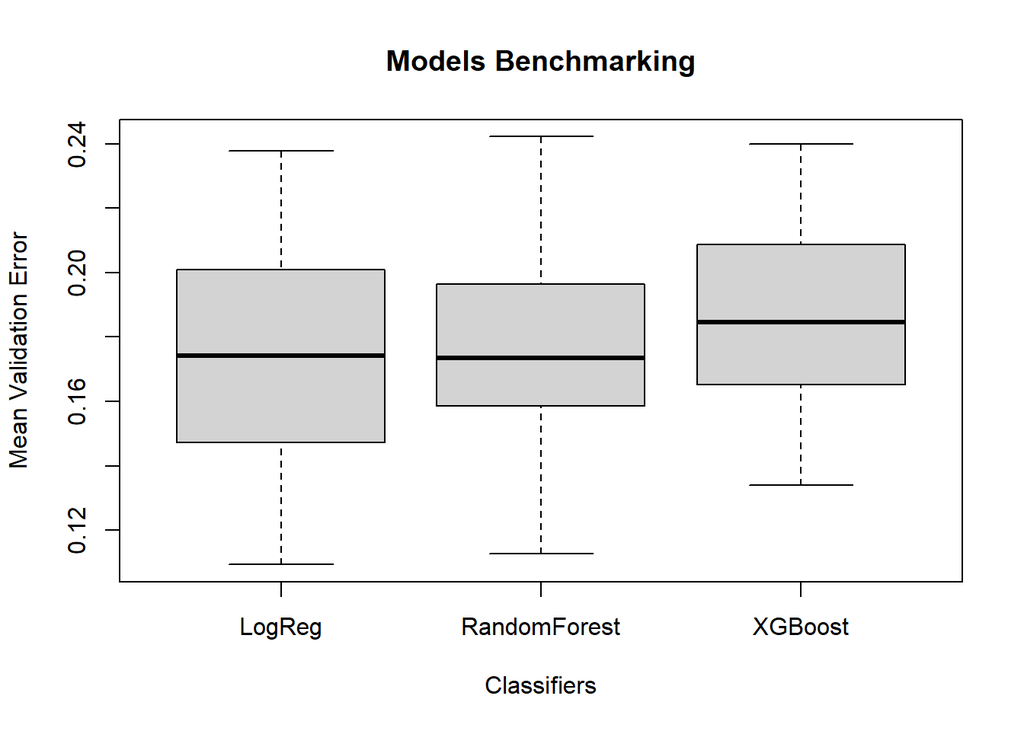

```r
boxplot(models_comparator(predictors[1:nrow(training_data),]), main = "Models Benchmarking", xlab = "Classifiers", ylab = "Mean Validation Error")
```

## Fine-tuning the model

Now that we know that Random Forest is likely the best algorithm for our binary classification problem, it is necessary to fine-tune the model in order to get even better results.

- Number of trees used:

In order to get a good representation of the tendency that the prediction error follows with the number of trees used, it was necessary to do the following things: + Perform cross-validation to quantify the validation error for each one of the models to compare. + Re-run the algorithm a number of times to take into consideration the variance of the different experiences we’ll be conducting.

```r
nb_tree_selector <- function(training_data){

  nb_iter <- 20

  # We choose the number of folds
  num_folds <- 6
  step <- as.integer(nrow(training_data)/num_folds)

  # Initialization of the temporary vector in order to store the testing errors after each CV iteration
  randomForest_errors_matrix <-  matrix(NA, nrow = nb_iter, ncol = 25)

      for (iteration in 1:nb_iter){

        shuffled_indices <- sample(1:nrow(training_data), replace = FALSE)
        randomForest_error <- matrix(NA, nrow = num_folds, ncol = 25)

        # Perform cross-validation
        for (fold in 1:num_folds) {

          # Create indices for training and testing data for this fold
          test_indices <- shuffled_indices[fold:(fold+step)]
          train_indices <- setdiff(1:nrow(training_data), test_indices)

          # Split the data into training and testing sets
          train_data <- training_data[train_indices, ]
          test_data <- training_data[test_indices, ]

          for (i in 1:25){
            # Compute the testing error for each model
            randomForest_error[fold,i] <- random_forest(train_data,test_data,i*10)$error
          }

        }
        # Compute the mean value
        for (i in 1:25){
          randomForest_errors_matrix[iteration,i]<- mean(randomForest_error[,i])
        }
      }


  return(as.data.frame(randomForest_errors_matrix))

}
```

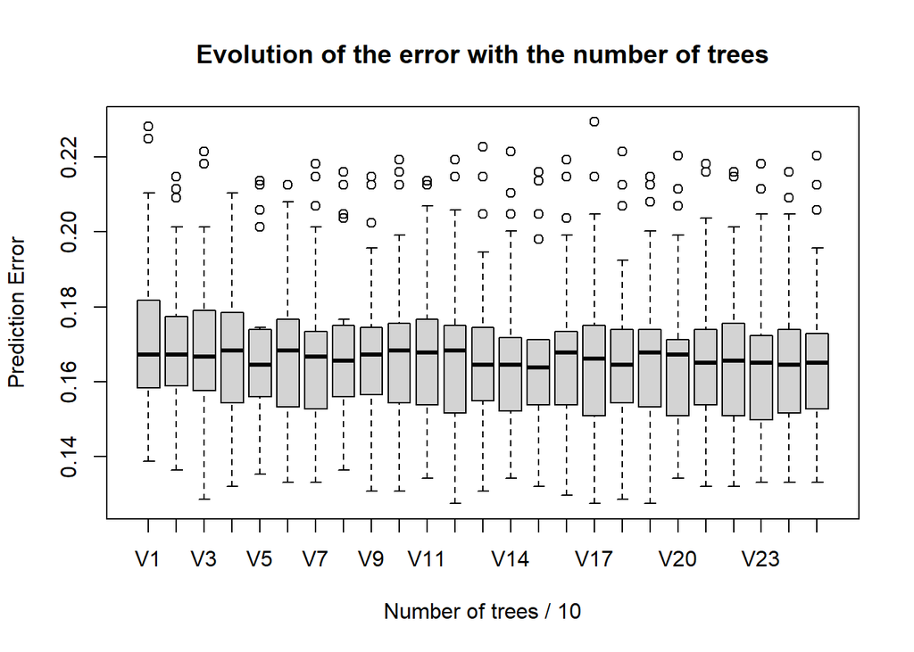

```r
boxplot(nb_tree_selector(predictors[1:nrow(training_data),]), main = "Evolution of the error with the number of trees", xlab = "Number of trees / 10", ylab = "Prediction Error")
```

It seems like the error is stabilized when the number of trees exceed ~100. We choose for instance 120.

- Choice of the optimal threshold

```r
random_forest_roc <- function(train,test,nb_tree){
  # Model training
  randomForestModel <- randomForest(Survived~.,data=train,ntree=nb_tree)
  # Make predictions on the testing data
  randomForestPredictions<-predict(randomForestModel, newdata=test[,-which(names(train)=="Survived")],type="response")
  # Define the ROC object (we'll use this later)
  roc_obj <- roc(test$Survived, randomForestPredictions)

  return(roc_obj)
}
```

```r
# Single time ROC Curve rendering

# Prepating the data
shuffled_indices <- sample(1:nrow(training_data), replace = FALSE)
train_indices <- seq(1, ceiling((5/6) * nrow(training_data)), by = 1)
test_indices <- setdiff(1:nrow(training_data), train_indices)

# Plot of the ROC curve
roc_obj <- random_forest_roc(predictors[train_indices,],predictors[test_indices,],120)
results <- coords(roc_obj,"best",best.method="closest.topleft", ret=c("threshold", "accuracy"))
results
```

|  | threshold | accuracy |
| --- | --- | --- |
| threshold | 0.2795531 | 0.8445946 |

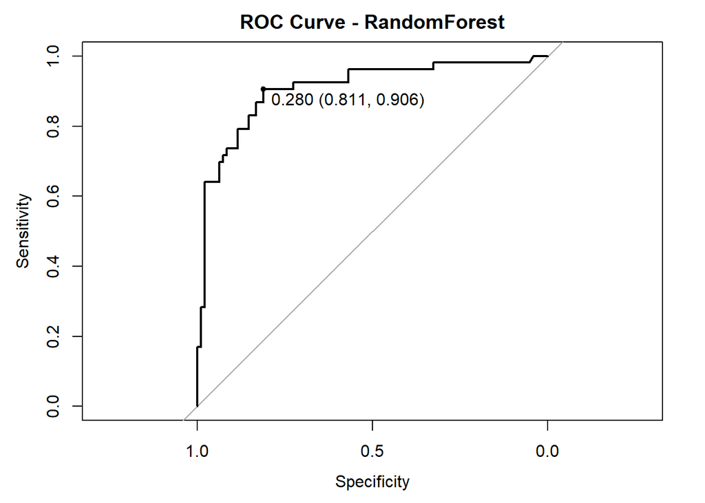

```r
plot(roc_obj, main = "ROC Curve - RandomForest", print.thres="best", print.thres.best.method="closest.topleft")
```

In order to get a fair estimation of this value, let’s perform cross-validation.

```r
optimal_threshold_estimator <- function(training_data){

  # Setting of the number of times we'll be re-running the benchmark
  nb_iter <- 30

  # We choose the number of folds
  num_folds <- 7
  step <- as.integer(nrow(training_data)/num_folds)

  optimal_threshold <- numeric(nb_iter)

  for (i in 1:nb_iter){

    shuffled_indices <- sample(1:nrow(training_data), replace = FALSE)
    folds_optimal_threshold <- numeric(num_folds)

    # Perform cross-validation
    for (fold in 1:num_folds) {

      # Create indices for training and testing data for this fold
      test_indices <- shuffled_indices[fold:(fold+step)]
      train_indices <- setdiff(1:nrow(training_data), test_indices)

      # Split the data into training and testing sets
      train_data <- training_data[train_indices, ]
      test_data <- training_data[test_indices, ]

      # Compute the optimal threshold
      randomForest_roc_obj <- random_forest_roc(train_data,test_data,120)
      folds_optimal_threshold[fold] <- coords(randomForest_roc_obj, "best", best.method="closest.topleft",ret=c("threshold", "accuracy"))$threshold

    }

    optimal_threshold[i] <- mean(folds_optimal_threshold)
  }
  return(as.data.frame(mean(optimal_threshold)))
}
```

```r
optimal_threshold_estimator(predictors[1:nrow(training_data),])
```

| mean(optimal_threshold) |
| --- |
| 0.3789024 |

After running this previous script a number of times, the optimal value computed is often less than 0.5 . This was expected since the majority of individuals inside the data set didn’t survive. Which means that these values are a bit biased by this trait. Moreover, we are trying to avoid overfitting so choosing one of the computed values wouldn’t be the best way to go. Therefore, we will be choosing a threshold of around 0.48.

## Final prediction and Conclusion

```r
#which(is.na(predictors[nrow(training_data)+1:nrow(predictors),-which(names(predictors)=="Survived")]))
#a <- predictors[,-which(names(predictors) %in% c("Parch","SibSp"))]
#pred <- random_forest(predictors[1:nrow(training_data),],predictors[nrow(training_data)+1:nrow(predictors),],120)
#a<- predictors
#a$Survived<-as.numeric(factor(a$Survived))
pred <- random_forest(predictors[1:nrow(training_data),],predictors[nrow(training_data)+1:nrow(predictors),],120)$predictions

#pred2 <- logistic_regression(a[1:nrow(training_data),],a[nrow(training_data)+1:nrow(predictors),])
#pred3 <- xg_Boost(predictors[1:nrow(training_data),],predictors[nrow(training_data)+1:nrow(predictors),])
#combined_pred <- rowMeans(cbind(0.8*pred, 1.2*pred2))
#combined_pred <- as.integer(combined_pred>0.48)

#combined_pred <- as.numeric((pred + pred2 + pred3) >= 2)
#as.data.frame(combined_pred)

final_sub <- as.data.frame(cbind(seq(892,1309,by=1),as.data.frame(pred)[1:nrow(testing_data),]))
colnames(final_sub) <- c("PassengerId","Survived")
final_sub$Survived <- as.integer(final_sub$Survived)

write.csv(final_sub, "sub0.csv", row.names = FALSE)
```

As you can see, many things were tried:

- Random Forest
- Logistic Regression
- XGBoost
- Hybrid method (put some or all of the methods into a vote / weighted combination of probabilities…)
- Different combinations of columns

We tried KNN as well, but we all know that it’s main weakness is that it can’t handle categorical data since features are not of the same scale. In fact, we tried also to convert the different levels to numeric values but this didn’t lead to some great result which is likely due to the fact that we are setting a certain hierarchy between them.

But even with everything that was included in this notebook and other things that were tried as well , the best accuracy we achieved is of 0.78 (Ranking : 3488 / Aymane Haoulani) which is a bit unfortunate looking at the amount of effort and time that was put into this project. But it was definitely a great learning experience dealing with real-world data. And thanks again for this great introduction to Kaggle!